# ARIMA Forecasting: Temporal Inequality in Vaccination Progress

## Figure 15: K-means Clustering in PCA Space (k = 3)

Cluster labels below are derived from each cluster’s own computed mean coverage (highest → “high-coverage”, lowest → “low-coverage”), not from the arbitrary numeric index k-means assigns — that index is not guaranteed to be consistent across runs, R versions, or package versions, even with a fixed seed.

```r
set.seed(42)
km <- kmeans(scaled_pca_data, centers = 3, nstart = 25)

cluster_means <- pca_input %>%
  mutate(cluster_id = factor(km$cluster)) %>%
  group_by(cluster_id) %>%
  summarise(n_countries = n(),
            mean_fully_vaccinated = mean(people_fully_vaccinated_per_hundred, na.rm = TRUE),
            .groups = "drop") %>%
  arrange(desc(mean_fully_vaccinated))

print(cluster_means)
```

```
## # A tibble: 3 × 3
##   cluster_id n_countries mean_fully_vaccinated
##   <fct>            <int>                 <dbl>
## 1 1                   70                 59.7
## 2 2                   35                 32.7
## 3 3                  104                  8.87
```

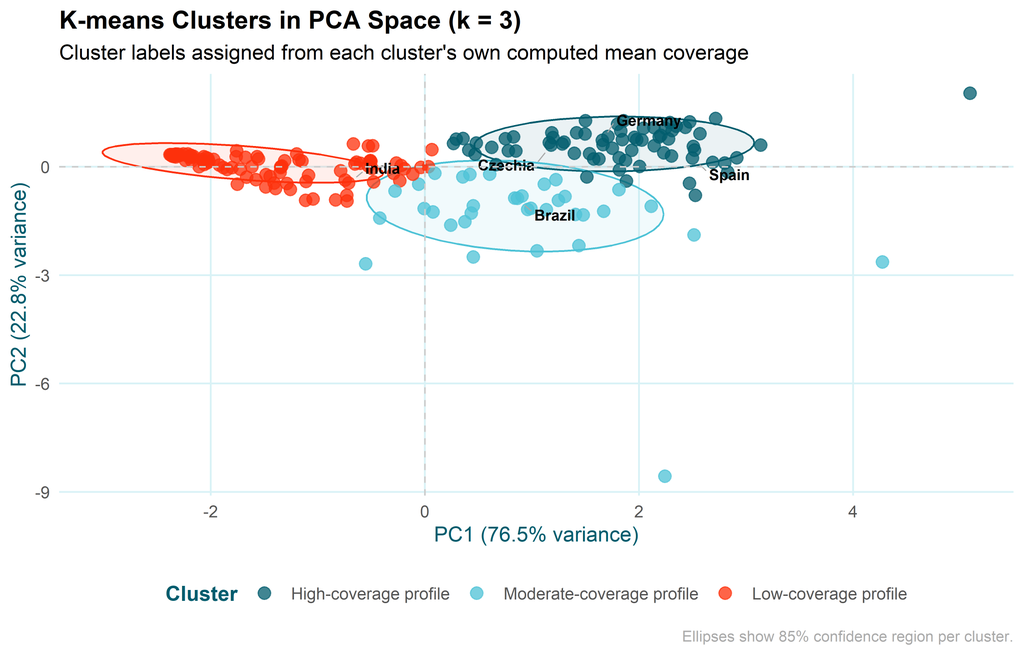

```r
cluster_label_order <- c("High-coverage profile", "Moderate-coverage profile", "Low-coverage profile")
label_map <- setNames(cluster_label_order[seq_len(nrow(cluster_means))], as.character(cluster_means$cluster_id))

pca_scores <- pca_scores %>%
  mutate(cluster_id = factor(km$cluster),
         cluster = factor(recode(as.character(cluster_id), !!!label_map), levels = cluster_label_order))

cluster_colors_named <- setNames(c(teal_dark, teal_light, red_mid), cluster_label_order)

ggplot(pca_scores, aes(PC1, PC2, color = cluster)) +
  stat_ellipse(aes(fill = cluster), geom = "polygon", alpha = 0.08, level = 0.85, show.legend = FALSE) +
  geom_point(alpha = 0.75, size = 2.8) +
  geom_text_repel(data = pca_scores %>% filter(location %in% label_countries),
                   aes(label = location), size = 2.8, color = "black", fontface = "bold",
                   max.overlaps = 30, box.padding = 0.5, point.padding = 0.3,
                   segment.color = "#AAAAAA", segment.size = 0.3, min.segment.length = 0.2) +
  geom_hline(yintercept = 0, linetype = "dashed", color = "#CCCCCC", linewidth = 0.4) +
  geom_vline(xintercept = 0, linetype = "dashed", color = "#CCCCCC", linewidth = 0.4) +
  scale_color_manual(values = cluster_colors_named) +
  scale_fill_manual(values = cluster_colors_named) +
  labs(title = "K-means Clusters in PCA Space (k = 3)",
       subtitle = "Cluster labels assigned from each cluster's own computed mean coverage",
       x = paste0("PC1 (", round(summary(pca)$importance[2,1]*100,1), "% variance)"),
       y = paste0("PC2 (", round(summary(pca)$importance[2,2]*100,1), "% variance)"),
       color = "Cluster", caption = "Ellipses show 85% confidence region per cluster.") +
  guides(color = guide_legend(nrow = 1, byrow = TRUE)) +
  theme_teal() +
  theme(legend.position = "bottom", legend.direction = "horizontal", legend.box = "horizontal",
        plot.caption = element_text(size = 8, color = "#AAAAAA", hjust = 1))
```

K-means identifies 3 structurally distinct groups. “High-coverage profile” is the highest-coverage group (70 countries, mean 59.7 fully vaccinated per 100); “Low-coverage profile” is the lowest (104 countries, mean 8.9).

## Final Summary Table

```r
final_summary <- latest_country %>%
  select(location, date, people_fully_vaccinated_per_hundred) %>%
  left_join(rollout_speed %>% select(location, reached_50, days_to_50), by = "location") %>%
  left_join(missing_country, by = "location") %>%
  arrange(desc(people_fully_vaccinated_per_hundred))

head(final_summary, 20)
```

```
## # A tibble: 20 × 6
##    location  date       people_fully_vaccina…¹ reached_50 days_to_50 missing_pct
##    <chr>     <date>                      <dbl> <lgl>           <dbl>       <dbl>
##  1 Gibraltar 2021-08-27                  116.  TRUE               42      50.9
##  2 Malta     2021-08-27                   80.0 TRUE              138       3.59
##  3 Iceland   2021-08-27                   76.8 TRUE              155      63.5
##  4 Pitcairn  2021-08-02                   76.6 TRUE                0      95.9
##  5 UAE       2021-08-26                   74.2 TRUE              176      80.9
##  6 Singapore 2021-08-27                   74.0 TRUE              177      70.7
##  7 Cayman I… 2021-08-24                   73.8 TRUE               98      71.1
##  8 Portugal  2021-08-28                   73.6 TRUE              193      12.7
##  9 Uruguay   2021-08-28                   71.6 TRUE               95      16.4
## 10 Isle of … 2021-08-24                   71.6 TRUE              157      35.2
## 11 Denmark   2021-08-27                   71.4 TRUE              200       7.09
## 12 Jersey    2021-08-22                   71.0 TRUE               91      77.2
## 13 Seychell… 2021-08-09                   70.5 TRUE               75      76.5
## 14 San Mari… 2021-08-25                   70.4 TRUE               66      60.6
## 15 Qatar     2021-08-28                   70.2 TRUE               64      52.8
## 16 Chile     2021-08-27                   70.2 TRUE              160       8.10
## 17 Faeroe I… 2021-08-26                   69.5 TRUE              164      55.2
## 18 Spain     2021-08-26                   69.4 TRUE              178      32.3
## 19 Belgium   2021-08-26                   68.8 TRUE              204       0.413
## 20 Wales     2021-08-26                   68.6 TRUE              165      11.7
## # ℹ abbreviated name: ¹people_fully_vaccinated_per_hundred
```

## Summary

```r
knitr::opts_chunk$set(
  echo = TRUE, fig.width = 7.5, fig.height = 4.5,
  fig.path = "figures/arima/", dev = "png", dpi = 300
)

library(dplyr)
library(tibble)
library(ggplot2)
library(forecast)
library(tseries)
library(zoo)
library(forecast)

# ---- Colour palette (kept identical to vaccination_pipeline.Rmd for visual
# consistency across the two deliverables) ---------------------------------
teal_dark   <- "#015c6d"
teal_mid    <- "#017a8f"
teal_base   <- "#019ab5"
teal_light  <- "#4dc2d6"
teal_pale   <- "#a8e2ec"
teal_ghost  <- "#d9f2f6"

red_dark    <- "#c02200"
red_mid     <- "#fd300b"
red_base    <- "#fd5a38"
red_light   <- "#fe8a70"

theme_teal <- function() {
  theme_minimal() +
    theme(
      plot.title       = element_text(face = "bold", colour = "black"),
      plot.subtitle    = element_text(colour = "black"),
      axis.title       = element_text(colour = teal_dark),
      axis.text        = element_text(colour = "#555555"),
      legend.title     = element_text(colour = teal_dark, face = "bold"),
      panel.grid.major = element_line(colour = teal_ghost),
      panel.grid.minor = element_blank()
    )
}
```

## Data Loading and Cleaning

This mirrors the loading step in `vaccination_pipeline.Rmd`. It is repeated here (rather than assumed) so that this notebook can be knit independently.

```r
vaccinations <- read.csv("vaccinations.csv", sep = ",", stringsAsFactors = FALSE)

vaccinations_clean <- vaccinations %>%
  mutate(
    date = as.Date(date),
    across(
      c(total_vaccinations_per_hundred,
        people_vaccinated_per_hundred,
        people_fully_vaccinated_per_hundred,
        total_boosters_per_hundred),
      ~ suppressWarnings(as.numeric(.x))
    )
  )

regional_aggregates <- c(
  "World", "Europe", "European Union", "Asia", "Africa",
  "North America", "South America", "Oceania",
  "High income", "Upper middle income",
  "Lower middle income", "Low income"
)

vaccinations_country <- vaccinations_clean %>%
  filter(!location %in% regional_aggregates)
```

## Preparing Clean, Gap-Free Time Series

The raw reporting calendar has gaps: not every country reports on every calendar day. For Germany, every date in range has a value, but for India and Bangladesh there are real gaps (multi-day jumps between reported observations). Passing a vector with silent gaps straight into `ts(..., frequency = 7)` is a bug — it assumes row *position*, not the actual calendar date, defines the weekly cycle, which misaligns the seasonal index whenever a country has skipped days. This function builds a complete daily calendar for a country and linearly interpolates missing values (with `rule = 2` so the first/last known value is carried to the edges) before any time series object is created.

```r
prepare_country_series <- function(data, loc, value_col) {
  d <- data %>%
    filter(location == loc, !is.na(.data[[value_col]])) %>%
    arrange(date) %>%
    select(date, value = all_of(value_col))

  full_dates <- tibble(date = seq(min(d$date), max(d$date), by = "day"))

  d_full <- full_dates %>% left_join(d, by = "date")

  value_zoo <- zoo::zoo(d_full$value, order.by = d_full$date)
  d_full$value <- as.numeric(zoo::na.approx(value_zoo, rule = 2))

  d_full
}

n_gaps <- function(data, loc, value_col) {
  d <- data %>% filter(location == loc, !is.na(.data[[value_col]])) %>% arrange(date)
  sum(diff(d$date) > 1)
}

for (ctry in c("Germany", "India", "Bangladesh")) {
  cat(sprintf(
    "%s: %d reported dates with a gap of more than 1 day before interpolation\n",
    ctry, n_gaps(vaccinations_country, ctry, "people_fully_vaccinated_per_hundred")
  ))
}
```

```
## Germany: 0 reported dates with a gap of more than 1 day before interpolation
## India: 10 reported dates with a gap of more than 1 day before interpolation
## Bangladesh: 32 reported dates with a gap of more than 1 day before interpolation
```

## Germany: ARIMA Model

```r
germany_series <- prepare_country_series(
  vaccinations_country, "Germany", "people_fully_vaccinated_per_hundred"
)

ts_germany <- ts(germany_series$value, frequency = 7)
```

The cumulative coverage series is, by construction, monotonically non-decreasing, so it is not stationary in levels. Rather than assuming a fixed order of differencing, `auto.arima()` is left to select `d` and `D` itself (via its internal KPSS/OCSB unit-root tests), which is a more defensible default than hard-coding `d = 1, D = 1` up front.

```r
fit_germany <- auto.arima(ts_germany, stepwise = FALSE, approximation = FALSE)
summary(fit_germany)
```

```
## Series: ts_germany
## ARIMA(2,2,1)(2,1,0)[7]
##
## Coefficients:
##          ar1      ar2      ma1     sar1     sar2
##       0.7495  -0.4378  -0.7522  -0.4577  -0.3359
## s.e.  0.0711   0.0610   0.0562   0.0628   0.0604
##
## sigma^2 = 0.00263:  log likelihood = 361.94
## AIC=-711.87   AICc=-711.51   BIC=-691.12
##
## Training set error measures:
##                        ME       RMSE        MAE       MPE     MAPE       MASE
## Training set -0.001647827 0.04979226 0.03056362 0.7844165 1.395526 0.01753978
##                     ACF1
## Training set -0.05566601
```

```r
cat("\nSelected order (p, d, q)(P, D, Q)[m]:\n")
```

```
##
## Selected order (p, d, q)(P, D, Q)[m]:
```

```r
print(arimaorder(fit_germany))
```

```
##         p         d         q         P         D         Q Frequency
##         2         2         1         2         1         0         7
```

```r
plot_forecast_teal <- function(fc, title_text, y_label) {
  fitted_vals <- as.numeric(fc$x)
  forecast_vals <- as.numeric(fc$mean)

  n_fitted <- length(fitted_vals)
  n_fore   <- length(forecast_vals)

  fitted_df <- data.frame(t = seq_len(n_fitted), value = fitted_vals)

  fore_df <- data.frame(
    t    = n_fitted + seq_len(n_fore),
    mean = forecast_vals,
    lo80 = as.numeric(fc$lower[, 1]),
    hi80 = as.numeric(fc$upper[, 1]),
    lo95 = as.numeric(fc$lower[, 2]),
    hi95 = as.numeric(fc$upper[, 2])
  )

  ggplot() +
    geom_ribbon(data = fore_df, aes(x = t, ymin = lo95, ymax = hi95),
                fill = teal_pale, alpha = 0.6) +
    geom_ribbon(data = fore_df, aes(x = t, ymin = lo80, ymax = hi80),
                fill = teal_light, alpha = 0.7) +
    geom_line(data = fitted_df, aes(x = t, y = value),
              colour = "#555555", linewidth = 0.7) +
    geom_line(data = fore_df, aes(x = t, y = mean),
              colour = teal_base, linewidth = 1) +
    labs(
      title    = title_text,
      subtitle = "30-day forecast with 80% and 95% confidence intervals",
      x        = "Time (days)",
      y        = y_label
    ) +
    theme_teal()
}
```

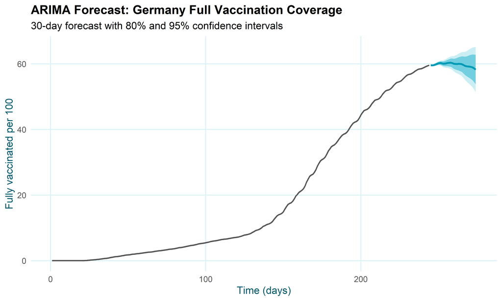

```r
forecast_30_germany <- forecast(fit_germany, h = 30)

plot_forecast_teal(
  forecast_30_germany,
  title_text = "ARIMA Forecast: Germany Full Vaccination Coverage",
  y_label    = "Fully vaccinated per 100"
)
```

## Residual Diagnostics

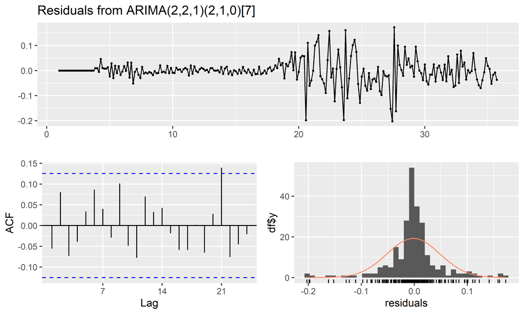

```
##
##  Ljung-Box test
##
## data:  Residuals from ARIMA(2,2,1)(2,1,0)[7]
## Q* = 13.724, df = 9, p-value = 0.1325
##
## Model df: 5.   Total lags used: 14
```

```r
checkresiduals(fit_germany)
```

The residual diagnostics above should be read directly from your own knit output rather than assumed: check that (1) residuals fluctuate around zero with no obvious trend, (2) the ACF shows no strong remaining autocorrelation beyond the seasonal lag (7, 14, …), and (3) the Ljung-Box p-value printed by `checkresiduals()` is not significant at your chosen alpha. If any of these fail, increase `max.p`/`max.q` in `auto.arima()` or reconsider the differencing order before trusting the forecast intervals.

## ETS Model Comparison

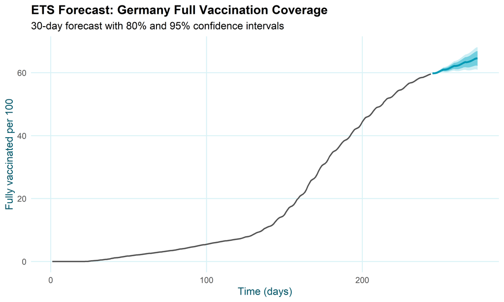

```r
fit_ets_germany <- ets(ts_germany)
fc_ets_germany  <- forecast(fit_ets_germany, h = 30)

plot_forecast_teal(
  fc_ets_germany,
  title_text = "ETS Forecast: Germany Full Vaccination Coverage",
  y_label    = "Fully vaccinated per 100"
)
```

## ARIMA vs ETS Accuracy (Train/Test Split)

```r
n_obs  <- length(ts_germany)
n_train <- round(n_obs * 0.8)

train_vals <- as.numeric(ts_germany)[1:n_train]
test_vals  <- as.numeric(ts_germany)[(n_train + 1):n_obs]

ts_train <- ts(train_vals, frequency = 7)

fit_arima_train <- auto.arima(ts_train, stepwise = FALSE, approximation = FALSE)
fit_ets_train   <- ets(ts_train)

h <- length(test_vals)

acc_arima <- accuracy(forecast(fit_arima_train, h = h), test_vals)
acc_ets   <- accuracy(forecast(fit_ets_train,   h = h), test_vals)

cat("ARIMA test-set accuracy:\n"); print(acc_arima)
```

```
## ARIMA test-set accuracy:
```

```
##                        ME       RMSE        MAE       MPE     MAPE      MASE
## Training set  0.002799666 0.05358339 0.03025888  1.180711 1.821364 0.1400006
## Test set     -1.623598100 2.44327396 1.68976747 -2.824448 2.969425 7.8181467
##                     ACF1
## Training set -0.03384741
## Test set              NA
```

```r
cat("\nETS test-set accuracy:\n");   print(acc_ets)
```

```
##
## ETS test-set accuracy:
```

```
##                       ME      RMSE        MAE       MPE     MAPE      MASE
## Training set  0.01788753 0.1155938 0.07218872       NaN      Inf 0.3339998
## Test set     -2.10150788 3.0487036 2.15450352 -3.675448 3.792284 9.9683683
##                   ACF1
## Training set 0.6184719
## Test set            NA
```

Compare the `RMSE`/`MAE` rows for the **Test set** between the two tables above (not the training-set rows) to decide which model generalises better for Germany; do not assume ARIMA is automatically the stronger model.

## Multi-Country ARIMA Forecast (Inequality Comparison)

Each of the three countries below is modelled the same way as Germany above — `auto.arima()` on the gap-filled **level** series, letting the function choose its own differencing order. This deliberately replaces the previous version’s approach, which manually first-differenced the series into `daily_change` *and then* still forced `d = 1, D = 1` inside `auto.arima()` — a double-differencing bug that over-differences an already-stationary series and destabilises the fitted model. Using one consistent modelling strategy across all countries also makes the cross-country forecast-uncertainty comparison below fair (like for like).

```
##
## Spain: n = 221, ADF p-value (levels) = 0.559, selected order = 1,1,1,1,1,1,7
```

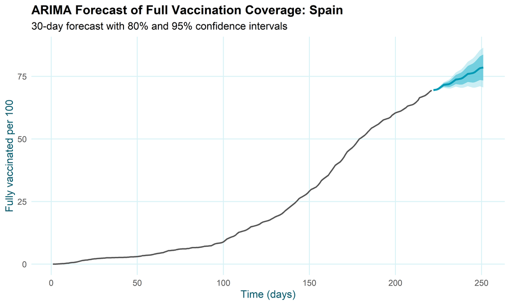

```
##
## India: n = 197, ADF p-value (levels) = 0.990, selected order = 0,2,2,2,0,0,7
```

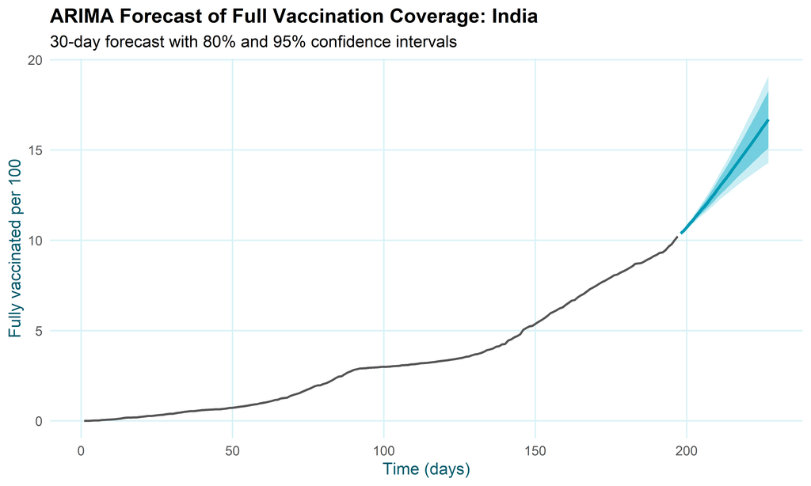

```
##
## Bangladesh: n = 141, ADF p-value (levels) = 0.951, selected order = 0,2,3,2,0,0,7
```

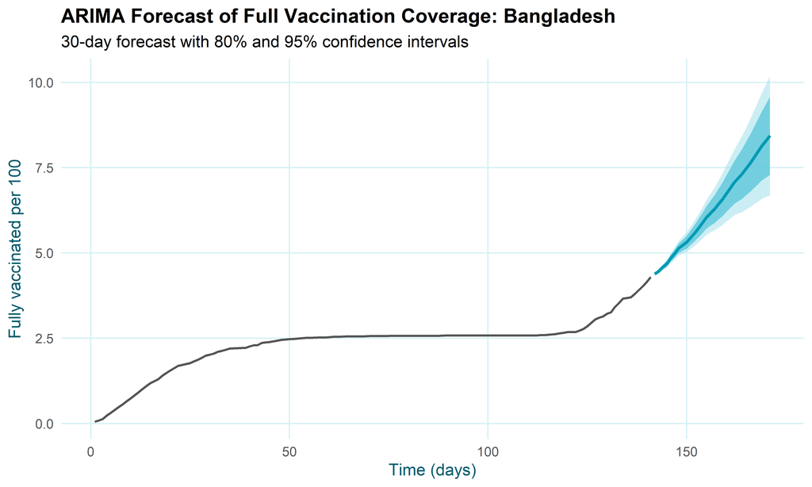

```r
countries_arima <- c("Spain", "India", "Bangladesh")
fits <- list()
forecasts <- list()

for (ctry in countries_arima) {

  series <- prepare_country_series(
    vaccinations_country, ctry, "people_fully_vaccinated_per_hundred"
  )

  if (nrow(series) < 21) {
    cat(sprintf("Skipping %s — fewer than 21 usable observations (n = %d)\n",
                ctry, nrow(series)))
    next
  }

  ts_ctry <- ts(series$value, frequency = 7)

  adf_p <- tryCatch(
    suppressWarnings(tseries::adf.test(ts_ctry)$p.value),
    error = function(e) NA_real_
  )

  fit_ctry <- auto.arima(ts_ctry, stepwise = FALSE, approximation = FALSE)
  fc_ctry  <- forecast(fit_ctry, h = 30)

  fits[[ctry]] <- fit_ctry
  forecasts[[ctry]] <- fc_ctry

  cat(sprintf(
    "\n%s: n = %d, ADF p-value (levels) = %s, selected order = %s\n",
    ctry, nrow(series),
    ifelse(is.na(adf_p), "NA", sprintf("%.3f", adf_p)),
    paste(arimaorder(fit_ctry), collapse = ",")
  ))

  print(
    plot_forecast_teal(
      fc_ctry,
      title_text = paste("ARIMA Forecast of Full Vaccination Coverage:", ctry),
      y_label    = "Fully vaccinated per 100"
    )
  )
}
```

## Quantifying Forecast Uncertainty as an Inequality Metric

Rather than comparing the three forecasts only by eye, this section computes a single number per country — the mean width of the 95% prediction interval across the 30-day forecast horizon — and treats it as a quantitative indicator of *data-driven planning uncertainty*. This ties the ARIMA analysis directly back to the report’s research question: it is one thing to say lower-income countries vaccinated more slowly, and another to show that the reliability of any forecast made from their own reported data is itself unequal.

```r
uncertainty_summary <- lapply(names(forecasts), function(ctry) {
  fc <- forecasts[[ctry]]
  width_95 <- as.numeric(fc$upper[, 2]) - as.numeric(fc$lower[, 2])
  mean_level <- mean(as.numeric(fc$mean))
  data.frame(
    country            = ctry,
    n_observations      = length(fc$x),
    mean_pi_width_95    = mean(width_95),
    max_pi_width_95     = max(width_95),
    # width scaled by the forecast's own average level, so a country
    # forecast to sit near 70% coverage isn't unfairly penalised for
    # having more absolute room to swing in than one still near 1%.
    relative_pi_width_95 = mean(width_95) / mean_level
  )
}) %>% bind_rows() %>% arrange(desc(mean_pi_width_95))

print(uncertainty_summary)
```

```
##      country n_observations mean_pi_width_95 max_pi_width_95
## 1      Spain            221         7.035675       15.879516
## 2      India            197         1.992396        4.825779
## 3 Bangladesh            141         1.411558        3.502532
##   relative_pi_width_95
## 1           0.09516634
## 2           0.14866145
## 3           0.22442874
```

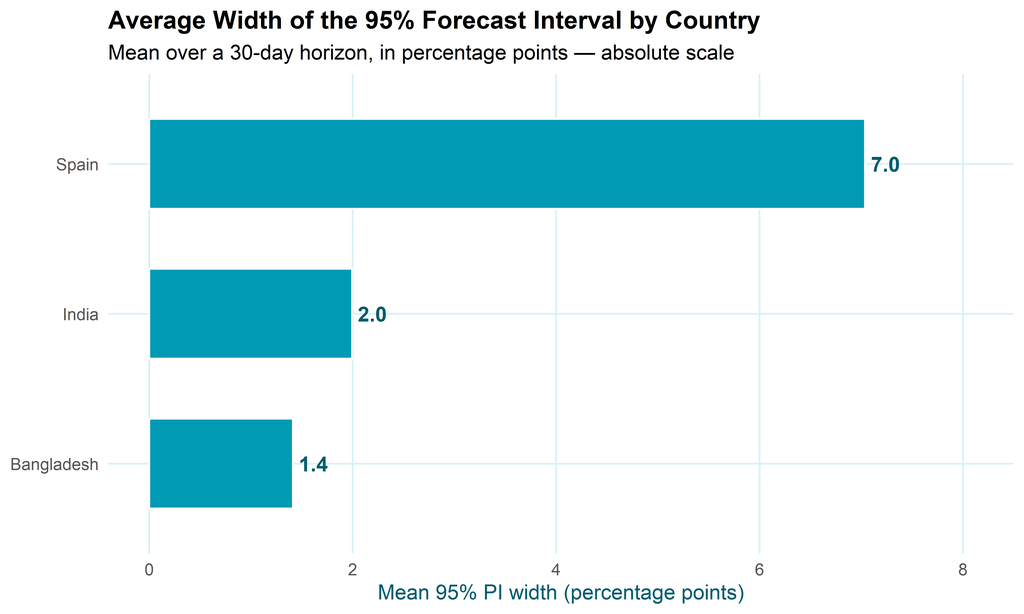

```r
ggplot(uncertainty_summary,
       aes(x = reorder(country, mean_pi_width_95), y = mean_pi_width_95)) +
  geom_col(fill = teal_base, width = 0.6, colour = "white") +
  geom_text(aes(label = sprintf("%.1f", mean_pi_width_95)),
            hjust = -0.2, colour = teal_dark, fontface = "bold") +
  coord_flip() +
  expand_limits(y = max(uncertainty_summary$mean_pi_width_95) * 1.15) +
  labs(
    title    = "Average Width of the 95% Forecast Interval by Country",
    subtitle = "Mean over a 30-day horizon, in percentage points — absolute scale",
    x        = NULL,
    y        = "Mean 95% PI width (percentage points)"
  ) +
  theme_teal()
```

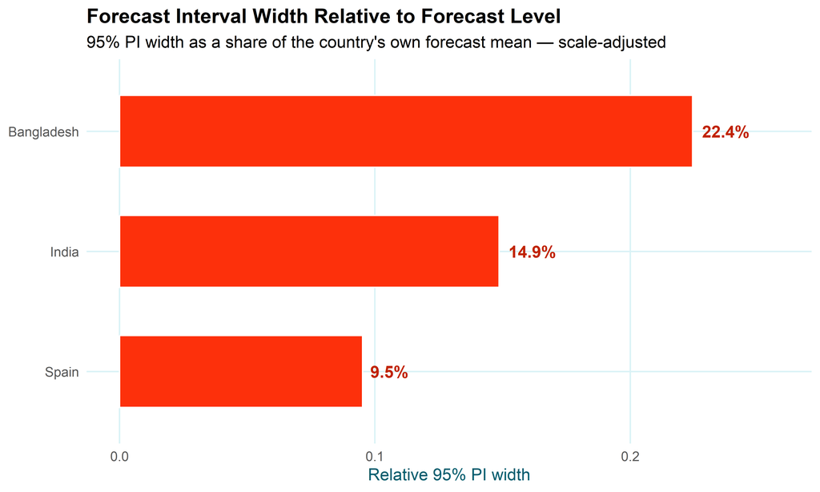

```r
ggplot(uncertainty_summary,
       aes(x = reorder(country, relative_pi_width_95), y = relative_pi_width_95)) +
  geom_col(fill = red_mid, width = 0.6, colour = "white") +
  geom_text(aes(label = scales::percent(relative_pi_width_95, accuracy = 0.1)),
            hjust = -0.2, colour = red_dark, fontface = "bold") +
  coord_flip() +
  expand_limits(y = max(uncertainty_summary$relative_pi_width_95) * 1.15) +
  labs(
    title    = "Forecast Interval Width Relative to Forecast Level",
    subtitle = "95% PI width as a share of the country's own forecast mean — scale-adjusted",
    x        = NULL,
    y        = "Relative 95% PI width"
  ) +
  theme_teal()
```

**Read the two charts above together, not just the first one.** In this run, Spain’s *absolute* 95% interval was the widest of the three (about 7.0 percentage points, versus roughly 2.0 for India and 1.4 for Bangladesh) — the opposite of the naive “richer country, more reliable data, narrower interval” story this section set out to test. That is worth reporting honestly rather than reinterpreted to fit the expectation. A plausible explanation, visible directly in the fitted orders: Spain’s model needed both non-seasonal *and* seasonal differencing (its `arimaorder()` shows `D = 1`), while India’s and Bangladesh’s models used only non-seasonal differencing — seasonal differencing compounds uncertainty faster over a 30-day horizon. Spain was also already close to saturation (around 70 fully vaccinated per 100) by the end of the series, where absolute week-to-week swings have more room to occur than in a series still crawling upward from near zero — which is exactly why the *relative* chart (interval width as a share of the forecast’s own level) is shown alongside the absolute one: if Spain’s relative ranking drops below India’s and Bangladesh’s once rescaled, that supports “more absolute room to move, not worse underlying data,” whereas if it stays highest even in relative terms, that’s stronger evidence of a genuine reliability gap. Whichever pattern your own numbers show, report the actual ranking from both charts, not the assumption stated at the start of this section.